# Exploratory Data Analysis of Preterm Birth DREAM Challenge

Martin Ruhle & Emiliano Jiménez

2024-08-03

## Introduction

This document presents an exploratory data analysis (EDA) of the preterm birth DREAM samples metadata file. The objective is to gain insights into the demographic characteristics and clinical data of the participants, as well as to understand the relationship between various demographic factors and pregnancy outcomes. Here we pin the Challenge full data description https://www.synapse.org/Synapse:syn26133770/wiki/618025.

```r
# Load necessary libraries
library(ggplot2)
library(dplyr)
library(polycor)
```

### Data Loading and Cleaning

We load the metadata file and perform basic cleaning step

```r
# Read the data
metadata <- read.csv("metadata.csv")
```

```r
# Basic Statistics and Structure
str(metadata)
```

```
## 'data.frame':    1895 obs. of  12 variables:
##  $ project               : chr  "A" "A" "A" "A" ...
##  $ specimen              : chr  "A00001-05" "A00002-01" "A00003-02" "A00004-08" ...
##  $ participant_id        : chr  "A00001" "A00002" "A00003" "A00004" ...
##  $ delivery_wk           : int  38 40 40 40 40 40 40 40 40 40 ...
##  $ was_term              : logi  TRUE TRUE TRUE TRUE TRUE TRUE ...
##  $ was_preterm           : logi  FALSE FALSE FALSE FALSE FALSE FALSE ...
##  $ was_early_preterm     : logi  FALSE FALSE FALSE FALSE FALSE FALSE ...
##  $ collect_wk            : int  33 38 30 27 29 30 33 35 37 39 ...
##  $ race                  : chr  "American Indian" "White" "Asian-Japanese" "White" ...
##  $ age                   : chr  "Unknown" "Unknown" "Unknown" "Unknown" ...
##  $ NIH.Racial.Category   : chr  "American Indian or Alaska Native" "White" "Asian" "White" ...
##  $ NIH.Ethnicity.Category: chr  "Unknown" "Unknown" "Unknown" "Unknown" ...
```

```r
summary(metadata)
```

```
##    project            specimen         participant_id      delivery_wk
##  Length:1895        Length:1895        Length:1895        Min.   :17.0
##  Class :character   Class :character   Class :character   1st Qu.:35.0
##  Mode  :character   Mode  :character   Mode  :character   Median :37.0
##                                                           Mean   :36.4
##                                                           3rd Qu.:39.0
##                                                           Max.   :42.0
##   was_term       was_preterm     was_early_preterm   collect_wk
##  Mode :logical   Mode :logical   Mode :logical     Min.   : 1.00
##  FALSE:672       FALSE:1223      FALSE:1668        1st Qu.:18.00
##  TRUE :1223      TRUE :672       TRUE :227         Median :25.00
##                                                    Mean   :24.25
##                                                    3rd Qu.:30.00
##                                                    Max.   :40.00
##      race               age            NIH.Racial.Category
##  Length:1895        Length:1895        Length:1895
##  Class :character   Class :character   Class :character
##  Mode  :character   Mode  :character   Mode  :character
##
##
##
##  NIH.Ethnicity.Category
##  Length:1895
##  Class :character
##  Mode  :character
##
##
##
```

```r
# Checking for missing values
colSums(is.na(metadata))
```

```
##                project               specimen         participant_id
##                      0                      0                      0
##            delivery_wk               was_term            was_preterm
##                      0                      0                      0
##      was_early_preterm             collect_wk                   race
##                      0                      0                      0
##                    age    NIH.Racial.Category NIH.Ethnicity.Category
##                      0                      0                      0
```

### Data Aggregation

Since one objective is to analyze data per participant, we aggregate the data to have one row per participant.

```r
# Creating a dataset with one row per participant
participant_data <- metadata %>%
  group_by(participant_id) %>%
  summarize(
    age = as.numeric(first(na.omit(age))),
    race = names(sort(table(race), decreasing = TRUE))[1],
    nih_racial_category = names(sort(table(`NIH.Racial.Category`), decreasing = TRUE))[1],
    nih_ethnicity_category = names(sort(table(`NIH.Ethnicity.Category`), decreasing = TRUE))[1],
    was_term = any(was_term == TRUE),
    was_preterm = any(was_preterm == TRUE),
    was_early_preterm = any(was_early_preterm == TRUE),
    delivery_wk = min(delivery_wk, na.rm = TRUE),
    collect_wk_earliest = min(collect_wk, na.rm = TRUE),
    collect_wk_latest = max(collect_wk, na.rm = TRUE),
    n_samples = n()
  )

# Basic Statistics for Participant-level Data
summary(participant_data)
```

```
##  participant_id          age           race           nih_racial_category
##  Length:616         Min.   :16.0   Length:616         Length:616
##  Class :character   1st Qu.:25.0   Class :character   Class :character
##  Mode  :character   Median :30.0   Mode  :character   Mode  :character
##                     Mean   :30.1
##                     3rd Qu.:35.0
##                     Max.   :51.0
##                     NA's   :40
##  nih_ethnicity_category  was_term       was_preterm     was_early_preterm
##  Length:616             Mode :logical   Mode :logical   Mode :logical
##  Class :character       FALSE:267       FALSE:349       FALSE:502
##  Mode  :character       TRUE :349       TRUE :267       TRUE :114
##
##
##
##
##   delivery_wk    collect_wk_earliest collect_wk_latest   n_samples
##  Min.   :17.00   Min.   : 1.00       Min.   : 9.00     Min.   : 1.000
##  1st Qu.:33.00   1st Qu.:15.00       1st Qu.:19.00     1st Qu.: 1.000
##  Median :37.00   Median :17.50       Median :28.00     Median : 2.000
##  Mean   :35.59   Mean   :19.66       Mean   :26.73     Mean   : 3.076
##  3rd Qu.:39.00   3rd Qu.:25.00       3rd Qu.:33.00     3rd Qu.: 4.000
##  Max.   :42.00   Max.   :40.00       Max.   :40.00     Max.   :22.000
##
```

```r
str(participant_data)
```

```
## tibble [616 × 12] (S3: tbl_df/tbl/data.frame)
##  $ participant_id        : chr [1:616] "A00001" "A00002" "A00003" "A00004" ...
##  $ age                   : num [1:616] NA NA NA NA NA NA NA NA NA NA ...
##  $ race                  : chr [1:616] "American Indian" "White" "Asian-Japanese" "White" ...
##  $ nih_racial_category   : chr [1:616] "American Indian or Alaska Native" "White" "Asian" "White" ...
##  $ nih_ethnicity_category: chr [1:616] "Unknown" "Unknown" "Unknown" "Unknown" ...
##  $ was_term              : logi [1:616] TRUE TRUE TRUE TRUE TRUE TRUE ...
##  $ was_preterm           : logi [1:616] FALSE FALSE FALSE FALSE FALSE FALSE ...
##  $ was_early_preterm     : logi [1:616] FALSE FALSE FALSE FALSE FALSE FALSE ...
##  $ delivery_wk           : int [1:616] 38 40 40 40 41 41 36 35 37 38 ...
##  $ collect_wk_earliest   : int [1:616] 33 38 30 27 26 31 34 17 25 27 ...
##  $ collect_wk_latest     : int [1:616] 33 38 30 39 40 33 34 33 36 35 ...
##  $ n_samples             : int [1:616] 1 1 1 7 8 2 1 6 5 5 ...
```

## Age Distribution

We analyze the distribution of participants’ ages and the relationship between age and term status.

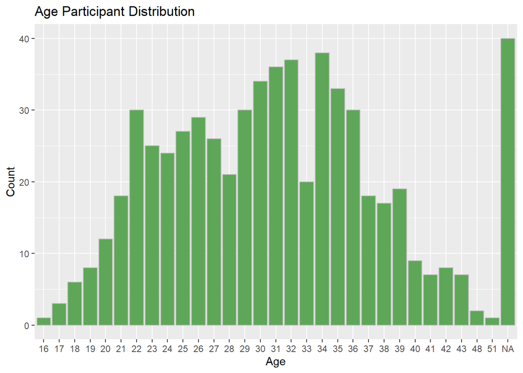

```r
# Convert the age column to a factor including NA's as a separate level
participant_data$age_factor <- factor(participant_data$age, exclude = NULL)

# Age Participant Distribution with NA's as a separate bin
ggplot(participant_data, aes(x = age_factor)) +
  geom_histogram(stat = "count", fill = "#5ea758", color = "grey") +
  xlab("Age") +
  ylab("Count") +
  ggtitle("Age Participant Distribution")
```

### Age and Preterm Correlation Analysis

In order to see if there are correlation between the age and the preterm and early preterm birth, we apply a point-biserial correlation analysis

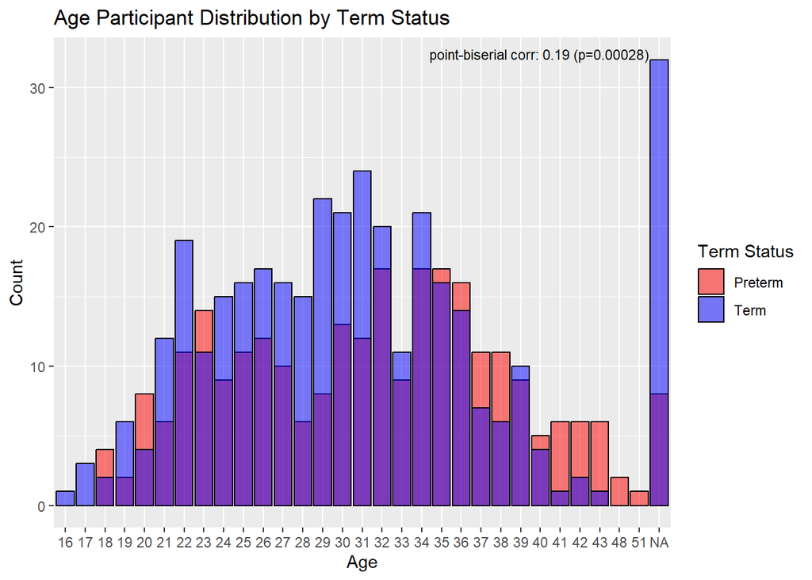

```r
# Convert logical columns to numeric
participant_data$was_preterm_num <- as.numeric(participant_data$was_preterm)
participant_data$was_early_preterm_num <- as.numeric(participant_data$was_early_preterm)

# Calculate the correlations
age_preterm_cor <- polyserial(participant_data$age, participant_data$was_preterm_num)
age_early_preterm_cor <- polyserial(participant_data$age, participant_data$was_early_preterm_num)
preterm_early_preterm_cor <- polychor(participant_data$was_preterm_num, participant_data$was_early_preterm_num)

# Calculate the p-values
age_preterm_test <- cor.test(participant_data$age, participant_data$was_preterm_num, method = "pearson")
age_early_preterm_test <- cor.test(participant_data$age, participant_data$was_early_preterm_num, method = "pearson")
preterm_early_preterm_test <- cor.test(participant_data$was_preterm_num, participant_data$was_early_preterm_num, method = "pearson")

# Create a formatted matrix with correlations and significance levels
formatted_matrix <- matrix(NA, nrow = 3, ncol = 3)
formatted_matrix[1, 1] <- "1.00"
formatted_matrix[1, 2] <- paste0(round(age_preterm_cor, 2), " (p=", format(age_preterm_test$p.value, digits = 2), ")")
formatted_matrix[1, 3] <- paste0(round(age_early_preterm_cor, 2), " (p=", format(age_early_preterm_test$p.value, digits = 2), ")")
formatted_matrix[2, 1] <- paste0(round(age_preterm_cor, 2), " (p=", format(age_preterm_test$p.value, digits = 2), ")")
formatted_matrix[2, 2] <- "1.00"
formatted_matrix[2, 3] <- paste0(round(preterm_early_preterm_cor, 2), " (p=", format(preterm_early_preterm_test$p.value, digits = 2), ")")
formatted_matrix[3, 1] <- paste0(round(age_early_preterm_cor, 2), " (p=", format(age_early_preterm_test$p.value, digits = 2), ")")
formatted_matrix[3, 2] <- paste0(round(preterm_early_preterm_cor, 2), " (p=", format(preterm_early_preterm_test$p.value, digits = 2), ")")
formatted_matrix[3, 3] <- "1.00"

# Overlaid Age Participant Distribution by was_term
ggplot(participant_data, aes(x = age_factor, fill = as.factor(was_term))) +
  geom_histogram(stat = "count", position = "identity", alpha = 0.5, color = "black") +
  xlab("Age") +
  ylab("Count") +
  ggtitle("Age Participant Distribution by Term Status") +
  scale_fill_manual(name = "Term Status", values = c("TRUE" = "blue", "FALSE" = "red"), labels = c("TRUE" = "Term", "FALSE" = "Preterm")) +
  annotate("text", x = Inf, y = Inf, label = paste("point-biserial corr:", format(formatted_matrix[1,2], digits = 2)), hjust = 1.1, vjust = 2, size = 3)
```

## Pregnancy and Delivery Details

### Term Status

We analyze the distribution of term, preterm, and early preterm statuses among participants.

```r
# Create the table
term_status <- table(participant_data$was_term, participant_data$was_preterm, participant_data$was_early_preterm)

# Add descriptive names to the dimensions
dimnames(term_status) <- list(
  Term_Status = c("Preterm", "Full-Term"),
  Preterm_Status = c("Full-Term", "Preterm"),
  Early_Preterm_Status = c("Not Early Preterm", "Early Preterm")
)

# Display the table with descriptive names
print(term_status)
```

```
## , , Early_Preterm_Status = Not Early Preterm
##
##            Preterm_Status
## Term_Status Full-Term Preterm
##   Preterm           0     153
##   Full-Term       349       0
##
## , , Early_Preterm_Status = Early Preterm
##
##            Preterm_Status
## Term_Status Full-Term Preterm
##   Preterm           0     114
##   Full-Term         0       0
```

```r
# Calculate percentages
total_births <- sum(term_status)
preterm_births <- sum(term_status[, "Preterm", ])
early_preterm_births <- sum(term_status[, , "Early Preterm"])

preterm_percentage <- (preterm_births / total_births) * 100
early_preterm_percentage <- (early_preterm_births / total_births) * 100

# Print the percentages
cat(sprintf("Percentage of Preterm Births: %.2f%%\n", preterm_percentage))
```

```
## Percentage of Preterm Births: 43.34%
```

```r
cat(sprintf("Percentage of Early Preterm Births: %.2f%%\n", early_preterm_percentage))
```

```
## Percentage of Early Preterm Births: 18.51%
```

These values are different from the values shown in the “2023 March of Dimes report card for United States” (https://www.marchofdimes.org/peristats/reports/united-states/report-card.), where the average precentage was 10,4%

### Delivery Week Distribution

We analyze the distribution of delivery weeks among participants and how it relates to term status.

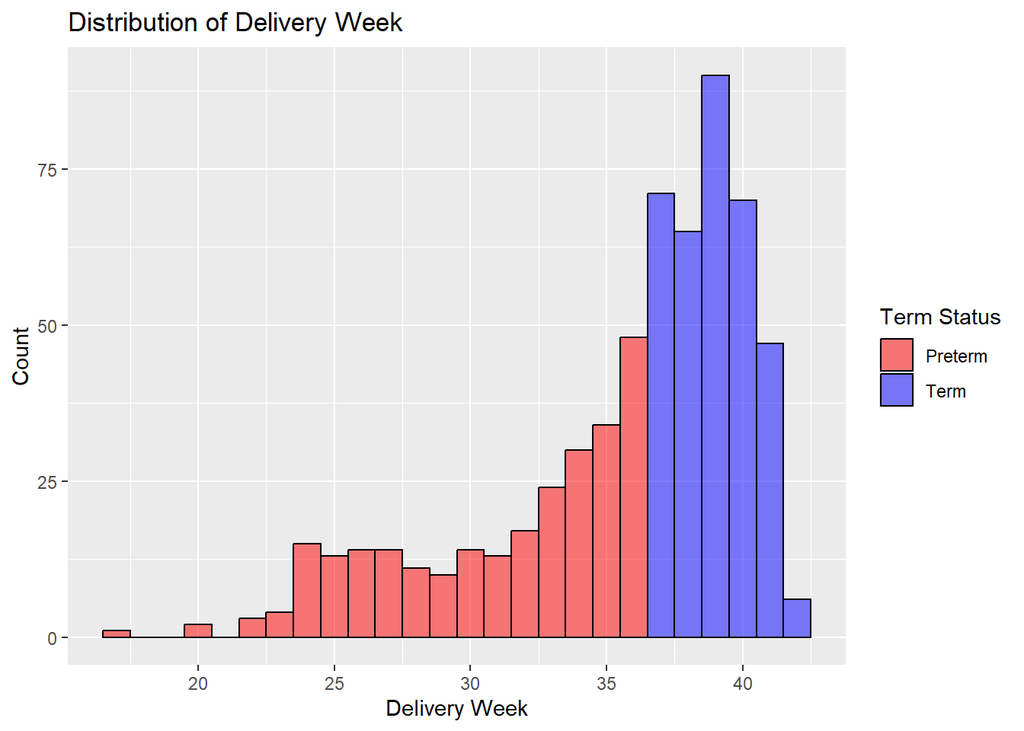

```r
# Plotting Delivery Week Distribution
ggplot(participant_data, aes(x = delivery_wk, fill = as.factor(was_term))) +
  geom_histogram(binwidth = 1, position = "identity", alpha = 0.5, color = "black") +
  xlab("Delivery Week") +
  ylab("Count") +
  ggtitle("Distribution of Delivery Week") +
  scale_fill_manual(name = "Term Status", values = c("TRUE" = "blue", "FALSE" = "red"), labels = c("TRUE" = "Term", "FALSE" = "Preterm"))
```

### Collection Week Distribution

We analyze the distribution of samples collection weeks, both the earliest and latest collection weeks, among participants.

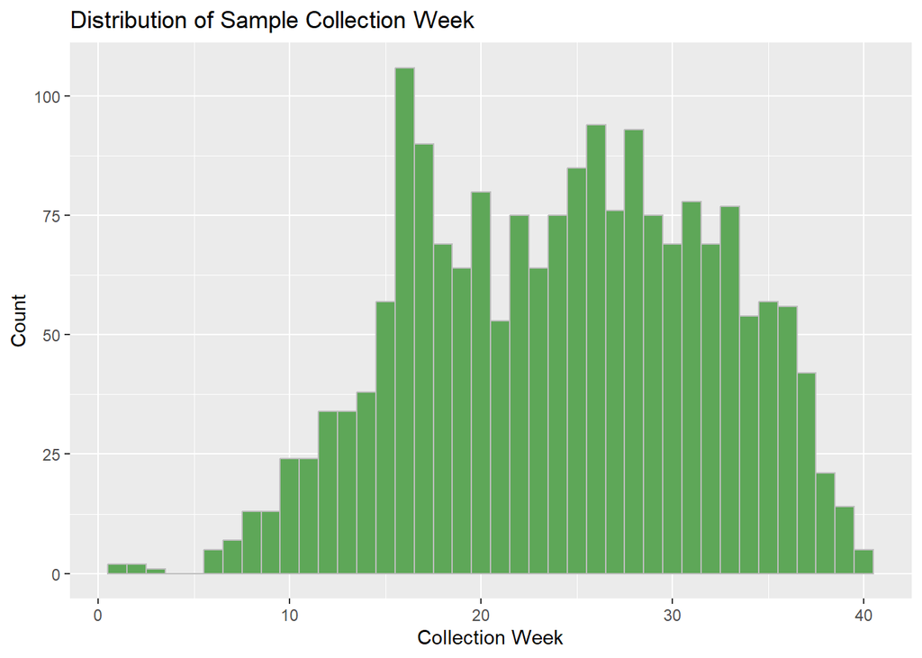

```r
# Plotting sample collection weeks
ggplot(metadata, aes(x = collect_wk)) +
  geom_histogram(binwidth = 1, fill = "#5ea758", color = "grey") +
  xlab("Collection Week") +
  ylab("Count") +
  ggtitle("Distribution of Sample Collection Week")
```

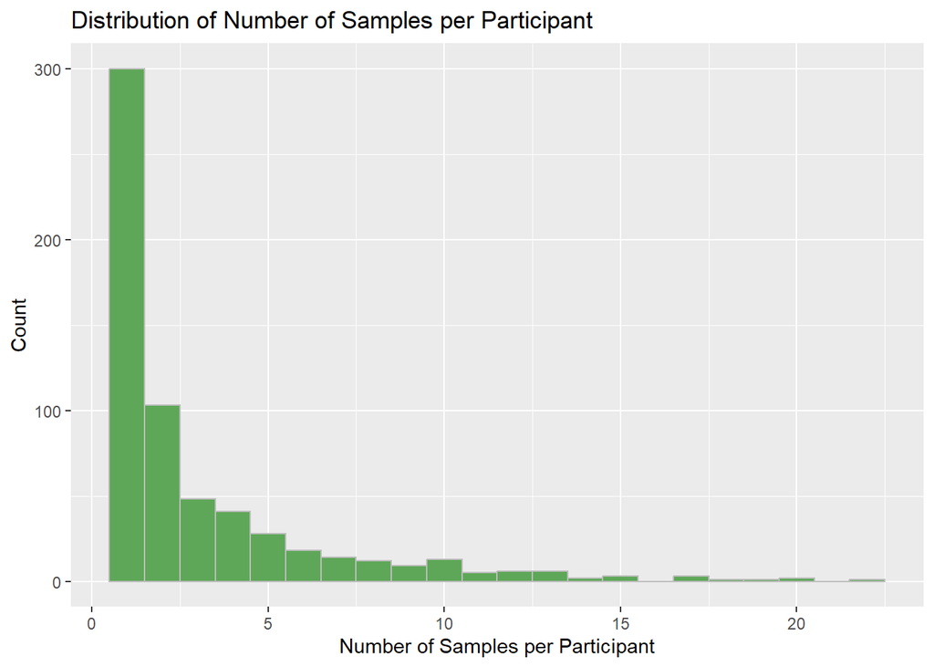

```r
# Distribution of Number of Samples per Participant
ggplot(participant_data, aes(x = n_samples)) +
  geom_histogram(binwidth = 1, fill = "#5ea758", color = "grey") +
  xlab("Number of Samples per Participant") +
  ylab("Count") +
  ggtitle("Distribution of Number of Samples per Participant")
```

To disgregate the distribution of the earliest, latest and single samples we add an extra column.

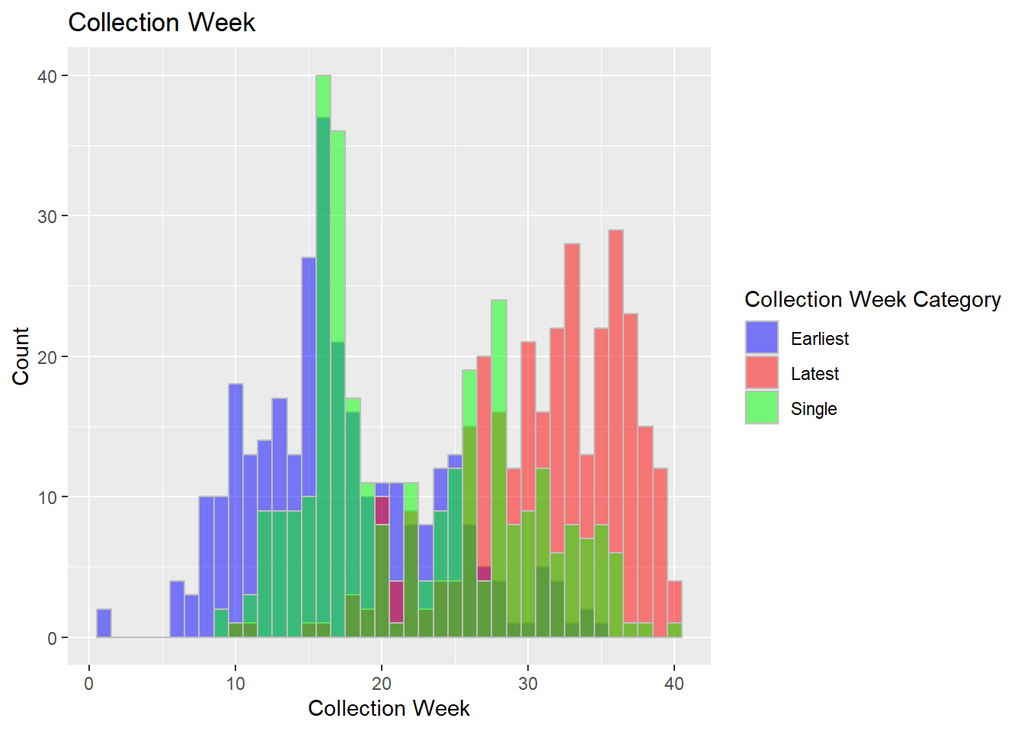

```r
# Categorize collection weeks
participant_data <- participant_data %>%
  mutate(
    collect_wk_category = case_when(
      collect_wk_earliest == collect_wk_latest ~ "single",
      TRUE ~ "multiple"
    )
  )

# Separate data for multiple and single categories
multiple_data <- participant_data %>% filter(collect_wk_category == "multiple")
single_data <- participant_data %>% filter(collect_wk_category == "single")

# Plotting Collection Week Distribution (Earliest and Latest)
ggplot() +
  geom_histogram(data = multiple_data, aes(x = collect_wk_earliest, fill = "Earliest"), binwidth = 1, color = "grey", alpha = 0.5, position = "identity") +
  geom_histogram(data = multiple_data, aes(x = collect_wk_latest, fill = "Latest"), binwidth = 1, color = "grey", alpha = 0.5, position = "identity") +
  geom_histogram(data = single_data, aes(x = collect_wk_earliest, fill = "single"), binwidth = 1, color = "grey", alpha = 0.5, position = "identity") +
  xlab("Collection Week") +
  ylab("Count") +
  ggtitle("Collection Week") +
  scale_fill_manual(name = "Collection Week Category", values = c("Earliest" = "blue", "Latest" = "red", "single" = "green"),
                    labels = c("Earliest", "Latest", "Single")) +
  theme(legend.position = "right")
```

### Race/Ethnicity Distribution

We analyze the distribution of NIH racial categories among the participants and perform a chi-squared test to examine the association between NIH racial categories and term status.

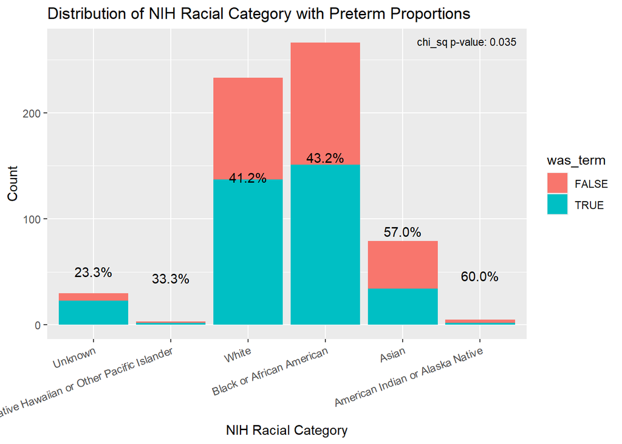

```r
# Race/Ethnicity Distribution
ethnicity_distribution <- table(participant_data$nih_racial_category)

# Perform chi-squared test
chi_sq_test <- chisq.test(table(participant_data$nih_racial_category, participant_data$was_term))

# Extract the p-value
p_value <- chi_sq_test$p.value

# Calculate the count and percentage for each combination of nih_racial_category and was_term
data_summary <- participant_data %>%
  group_by(nih_racial_category, was_term) %>%
  summarise(count = n(), .groups = 'drop') %>%
  group_by(nih_racial_category) %>%
  mutate(total_count = sum(count),
         percentage = count / total_count * 100) %>%
  filter(was_term == FALSE)  # Keep only rows where was_term is FALSE

# Order the levels of nih_racial_category by the percentage of FALSE
ordered_categories <- data_summary %>%
  arrange(percentage) %>%
  pull(nih_racial_category) %>%
  unique()

# Update participant_data with ordered categories
participant_data$nih_racial_category <- factor(participant_data$nih_racial_category, levels = ordered_categories)

# Plotting Distribution of NIH Racial Category with Preterm Proportions
ggplot(participant_data, aes(x = nih_racial_category, fill = was_term)) +
  geom_bar(position = "stack") +
  geom_text(data = data_summary,
            aes(y = count, label = sprintf("%.1f%%", percentage)),
            vjust = -4) +
  xlab("NIH Racial Category") +
  ylab("Count") +
  ggtitle("Distribution of NIH Racial Category with Preterm Proportions")+
  annotate("text", x = Inf, y = Inf, label = paste("chi_sq p-value:", format(p_value, digits = 2)), hjust = 1.1, vjust = 2, size = 3)+
  theme(axis.text.x = element_text(angle = 20, hjust = 1))
```

We can see that there is a significant difference between the proportions of the different ethnic groups. On the other hand the ethnic percetages of preterm birth are really different shown in the “2023 March of Dimes report card for United States” (https://www.marchofdimes.org/peristats/reports/united-states/report-card.). Not just the percentages, but also the order of the ethnic categories.

- Ethnic preterm precentages:
  - Asian – 9.0%
  - White – 9.4%
  - Hispanic – 10.1%
  - American Indian/Alaska Native – 12.2%
  - Pacific Islanders – 12.2%
  - Black – 14.6%